# Reproducible Research: Assignment 1

## Part One: Loading and preprocessing the data.

```r
activity <- read.csv("activity.csv", stringsAsFactors = FALSE)
```

## Part Two: What is the mean total number of steps taken per day?

### 1. Calculate the total number of steps taken per day.

```r
library(plyr)
per_day <- ddply(activity, .(date), summarise, steps_per_day = sum(steps))
```

### 2. Histogram showing total number of steps taken each day.

```
## stat_bin: binwidth defaulted to range/30. Use 'binwidth = x' to adjust this.
```

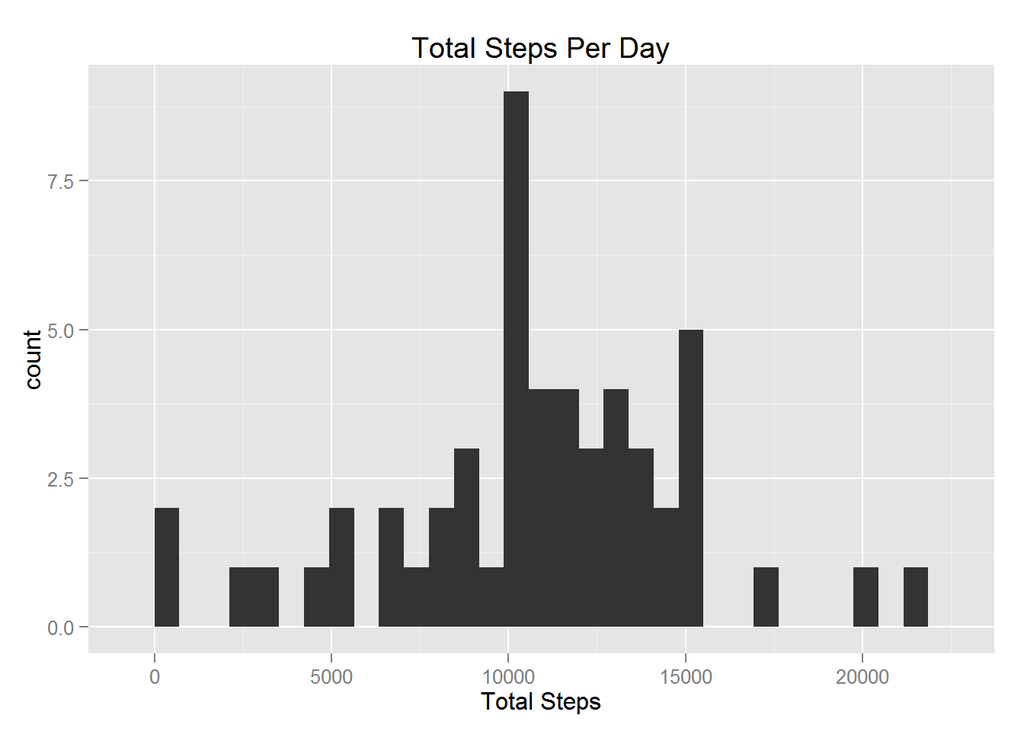

```r
library(ggplot2)
qplot(steps_per_day, data=per_day, geom = "histogram",
      main = "Total Steps Per Day", xlab = "Total Steps")
```

### 3. Mean and median steps per day.

```r
mean(per_day$steps, na.rm=TRUE)
```

```
## [1] 10766.19
```

```r
median(per_day$steps, na.rm=TRUE)
```

```
## [1] 10765
```

## Part Three: What is the average daily activity pattern?

### 1. Plot the 5-minute interval(x-axis) and the average number of steps taken across all days (y-axis).

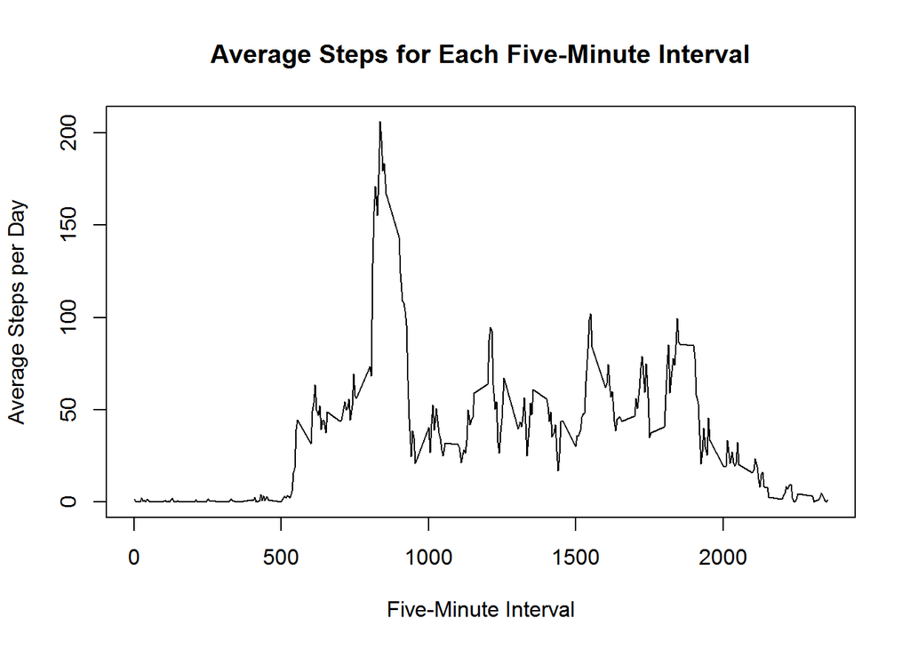

```r
library(plyr)
avg_steps <- ddply(activity, .(interval), summarise,
                   avg_steps_per_day = mean(steps, na.rm=TRUE))

plot(avg_steps$interval, avg_steps$avg_steps_per_day, type = "l",
     main = "Average Steps for Each Five-Minute Interval",
     xlab = "Five-Minute Interval", ylab = "Average Steps per Day")
```

## 2. Which 5-minute interval, on average across all the days contains the maximum number of steps?

```r
avg_steps[(which.max(avg_steps$avg_steps_per_day)), 1]
```

```
## [1] 835
```

## Part Four: Imputing missing values.

### 1. Total number of missing values in the dataset.

```r
sum(is.na(activity))
```

```
## [1] 2304
```

```r
library(plyr)
avg_steps <- ddply(activity, .(interval), summarise,
                   avg_steps_per_day = mean(steps, na.rm=TRUE))
```

### 3. Create a new dataset that is equal to the original dataset but with the missing data filled in.

```r
activity2 <- merge(activity, avg_steps, by = "interval", all.x = TRUE)
activity2$steps [which(is.na(activity2$steps))] <- activity2$avg_steps_per_day
library(dplyr)
activity2 <- select(activity2, -avg_steps_per_day)
```

```
## stat_bin: binwidth defaulted to range/30. Use 'binwidth = x' to adjust this.
```

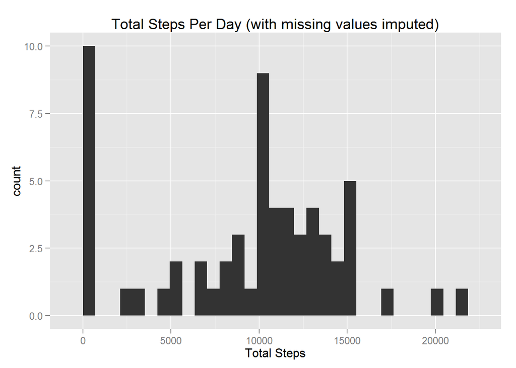

```r
library(plyr)
per_day2 <- ddply(activity2, .(date), summarise, steps_per_day = sum(steps))

library(ggplot2)
qplot(steps_per_day, data=per_day2, geom = "histogram",
      main = "Total Steps Per Day (with missing values imputed)", xlab = "Total Steps")
```

```r
mean(per_day2$steps)
```

```
## [1] 9371.437
```

```r
median(per_day2$steps)
```

```
## [1] 10395
```

## Part Five: Are there differences in activity patterns between weekdays and weekends?

### 1. Create new variable indicating whether given date is a weekday or weekend.

```r
activity2$days <- weekdays(as.Date(activity2$date))
activity2$weekdays[activity2$days %in% c('Monday', 'Tuesday', 'Wednesday', 'Thursday', 'Friday')] <- 'weekday'
activity2$weekdays[activity2$days %in% c('Saturday', 'Sunday')] <- 'weekend'
```

### 2. Panel plot containing time series plot of 5-minute interval (x axis) and average number of steps taken averaged across all weekdays or weekend days.

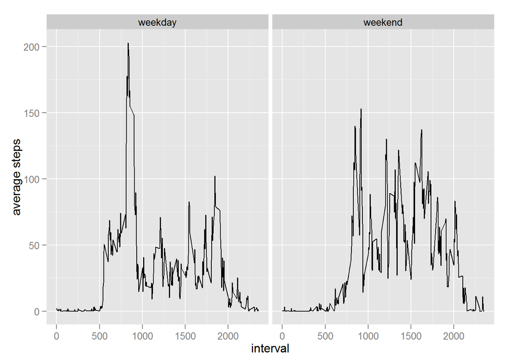

```r
library(plyr)
days_plot <- ddply(activity2, .(weekdays, interval), summarise, avg_steps = mean(steps))

library(ggplot2)
qplot(interval, avg_steps, data=days_plot, geom = "line", facets = .~weekdays, ylab = "average steps")
```